# 001712_IBL_Widefield_public_demo_raw_widefield_ipynb

## Installing requirements

The cell below installs every Python package needed to run this notebook, at fully pinned versions, using [`uv`](https://github.com/astral-sh/uv) for fast resolution. In Colab the cell is collapsed by default — click the ▶ button to run it.

```python
# install cell skipped during CI (deps preinstalled into system Python)
```

> **⚠️ Restart runtime after install**

> The install may upgrade packages already loaded in the kernel. Go to **Runtime → Restart session**, then **Run all cells below** (skip this install cell on re-run).

# IBL Widefield — Raw Data Tutorial

This tutorial shows how to access data from [DANDI:001712](https://dandiarchive.org/dandiset/001712/draft) for the IBL widefield dataset.

## Contents

1. Setup and Data Access
2. Session and Subject Metadata
3. Raw Imaging Data and Metadata
   - OnePhotonSeries
   - Imaging Metadata
4. Synchronization Signals
   - Digital Signals
   - Analog Signals
5. Behavior
   - Epochs (Task vs Passive)
   - Raw Video Data

# 1. Setup and Data Access

## Import Required Libraries

```python
# Visualization
import matplotlib.patches as mpatches
import matplotlib.pyplot as plt
import numpy as np

# Configure matplotlib
plt.rcParams['figure.figsize'] = (12, 6)
plt.rcParams['font.size'] = 10
```

# 2. Session and Subject Metadata

```python
from load_nwb_utils import *

dandiset_id = "001712"
subject_id = "FD-28"  # Example subject
session_id = "81f90b18-e61c-4d32-bbce-3e0c5f33f06c"  # EID for the session

# Choose data source (DANDI streaming or local)
USE_DANDI = True  # Set to False to use local files

if USE_DANDI:
    nwbfile, io = load_nwb_from_dandi(dandiset_id, subject_id, session_id, description="raw")
else:
    # TODO Specify your local directory path
    local_directory = f"E:/IBL-widefield-nwbfiles/full/"
    nwbfile, io = load_nwb_local(local_directory, subject_id, session_id, description="raw")

print("=== SESSION INFORMATION ===")
print(f"Experiment description:\n {nwbfile.experiment_description}")
print(f"Session description:\n {nwbfile.session_description}")
print(f"Session start time:\n {nwbfile.session_start_time}")
```

```
=== SESSION INFORMATION ===
Experiment description:
 In dynamic environments, updating beliefs based on past experiences (priors) is essential for optimal decision-making. Prior utilization is often impaired in psychiatric disorders, affecting perception and behavior. We investigate how Neurexin1α (Nrxn1α) loss-of-function disrupts this process, prov…

Session description:
 The task protocol(s) performed in this experimental session:
1. Biased choice world — the standard IBL data-collection task for trained mice. A Gabor patch appears at ±35° azimuth and the mouse turns a wheel to bring it to the center. Correct responses earn a water reward (~1.5 µL); incorrect responses trigger white noise and a 2s timeout. Stimulus probabilit…

Session start time:
 2023-11-14 12:10:33.757227-08:00
```

```python
print("\n=== SUBJECT INFORMATION ===")
print(f"ID: {nwbfile.subject.subject_id}")
print(f"DOB: {nwbfile.subject.date_of_birth}")
print(f"Strain: {nwbfile.subject.species}")
print(f"Genotype: {nwbfile.subject.genotype}")
print(f"Sex: {nwbfile.subject.sex}")
```

```
=== SUBJECT INFORMATION ===
ID: FD-28
DOB: 2022-12-08 00:00:00-08:00
Strain: Mus musculus
Genotype: None
Sex: F
```

# 3. Raw Imaging Data and Metadata

## OnePhotonSeries

Raw widefield imaging data are stored as `OnePhotonSeries` objects in the NWB file's `acquisition` module. Each excitation wavelength is added to a separate `OnePhotonSeries` object.

Data shape

- Arrays are shaped `(time, num_rows, num_columns)` — the first dimension is time (frame), the second and third are the height and width of the image.

Series names

- Calcium (470 nm): `OnePhotonSeriesCalcium`
- Isosbestic (405 nm): `OnePhotonSeriesIsosbestic`

Access example

```
calcium = nwbfile.acquisition['OnePhotonSeriesCalcium']
first_frame = calcium.data[0]  # lazy read of frame 0
```

```python
calcium_imaging = nwbfile.acquisition["OnePhotonSeriesCalcium"]

print("=== RAW WIDEFIELD CALCIUM SIGNAL ===")
print(f"Name: {calcium_imaging.name}")
print(f"Description: {calcium_imaging.description}")
print(f"Data shape: {calcium_imaging.data.shape}")
print(f"Duration: {calcium_imaging.timestamps[-1] - calcium_imaging.timestamps[0]:.2f} seconds")
```

```
=== RAW WIDEFIELD CALCIUM SIGNAL ===
Name: OnePhotonSeriesCalcium
Description: Widefield raw imaging under blue excitation at 470 nm (GCaMP signal). The dimensions are (time, height, width).
Data shape: (124886, 540, 640)
Duration: 3999.27 seconds
```

```python
isosbestic_imaging = nwbfile.acquisition["OnePhotonSeriesIsosbestic"]

print("=== RAW WIDEFIELD ISOSBESTIC SIGNAL ===")
print(f"Name: {isosbestic_imaging.name}")
print(f"Description: {isosbestic_imaging.description}")
print(f"Data shape: {isosbestic_imaging.data.shape}")
print(f"Duration: {isosbestic_imaging.timestamps[-1] - isosbestic_imaging.timestamps[0]:.2f} seconds")
```

```
=== RAW WIDEFIELD ISOSBESTIC SIGNAL ===
Name: OnePhotonSeriesIsosbestic
Description: Widefield raw imaging under violet excitation at 405 nm (isosbestic control). The dimensions are (time, height, width).
Data shape: (124886, 540, 640)
Duration: 3999.27 seconds
```

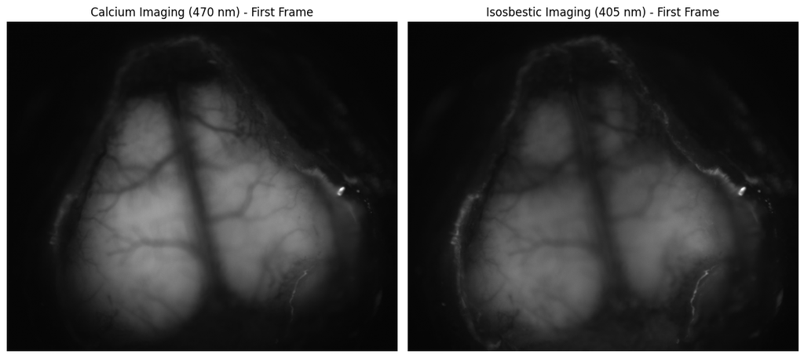

```python
# Plot with matplotlib (example)

fig, axes = plt.subplots(1, 2, sharex=True, sharey=True, dpi=100)
axes[0].imshow(calcium_imaging.data[0, ...], cmap='gray')
axes[0].set_title('Calcium Imaging (470 nm) - First Frame')
axes[0].axis('off')
axes[1].imshow(isosbestic_imaging.data[0, ...], cmap='gray')
axes[1].set_title('Isosbestic Imaging (405 nm) - First Frame')
axes[1].axis('off')
plt.tight_layout()
plt.show()
```

## Imaging Metadata

```python
print("=== IMAGING METADATA ===")
print("All imaging metadata are stored in the imaging module in imaging_planes:")
print("-" * 100)
for imaging_plane_name in nwbfile.imaging_planes:
    imaging_plane = nwbfile.imaging_planes[imaging_plane_name]
    print(f"Imaging Plane: {imaging_plane_name}")
    print("-" * 100)
    print(f"  Description: {imaging_plane.description}")
    print(f"  Imaging Rate: {imaging_plane.imaging_rate} Hz")
    print(f"  Optical Channel: {imaging_plane.optical_channel[0].name}, {imaging_plane.optical_channel[0].description}")
    print(f"  Indicator: {imaging_plane.indicator}")
    print(f"  Excitation Wavelength: {imaging_plane.excitation_lambda} nm")
    print(f"  Emission Wavelength: {imaging_plane.optical_channel[0].emission_lambda} nm")
    print(f"  Location: {imaging_plane.location}")
    print("-"*100)
```

```
=== IMAGING METADATA ===
All imaging metadata are stored in the imaging module in imaging_planes:
----------------------------------------------------------------------------------------------------
Imaging Plane: ImagingPlaneCalcium
----------------------------------------------------------------------------------------------------
  Description: The imaging plane for calcium imaging from Blue light excitation.
  Imaging Rate: 15.0 Hz
  Optical Channel: OpticalChannel, GCaMP Ca2+ bound emission (calcium signal). (Thorlabs, cat. no. M470L4)
  Indicator: GCaMP6f
  Excitation Wavelength: 470.0 nm
  Emission Wavelength: 510.0 nm
  Location: Whole Brain
----------------------------------------------------------------------------------------------------
Imaging Plane: ImagingPlaneIsosbestic
----------------------------------------------------------------------------------------------------
  Description: The imaging plane for calcium imaging from Violet light excitation.
  Imaging Rate: 15.0 Hz
  Optical Channel: OpticalChannel, GCaMP Ca2+ independent emission (isosbestic signal). (Thorlabs, cat. no. M405L4)
  Indicator: GCaMP6f
  Excitation Wavelength: 405.0 nm
  Emission Wavelength: 510.0 nm
  Location: Whole Brain
----------------------------------------------------------------------------------------------------
```

# 4. Synchronization Signals

## Digital Signals

```python
event_names = [name for name in nwbfile.acquisition if "Events" in name]
print("=== SYNCHRONIZATION EVENTS IN ACQUISITION ===")
print("-" * 100)
for name in event_names:
    print(f"  Name: {name}")
    print(f"  Description: {nwbfile.acquisition[name].description}")
```

```
=== SYNCHRONIZATION EVENTS IN ACQUISITION ===
----------------------------------------------------------------------------------------------------
  Name: EventsAudio
  Description: Auditory stimulus presentation events. Marks timing of audio stimulus delivery for auditory tasks or cue presentation.

Label meanings:
  - audio_off: Audio stimulus off
  - audio_on: Audio stimulus on
  Name: EventsBodyCamera
  Description: Video frame acquisition times for the body camera. Each event marks when a video frame was captured by the camera, enabling temporal alignment of behavior videos with neural and task data.

Label meanings:
  - exposure_end: Camera exposure end or frame readout complete
  - frame_start: Camera frame acquisition start (frame timestamp)
  Name: EventsFrame2ttl
  Description: Monitor refresh events detected by photodiode for visual stimulus timing. The Frame2TTL device uses a photodiode to detect changes in screen luminance, providing precise timing of when visual stimuli are displayed on the monitor. This is essential for accurate stimulus-response latenc…

Label meanings:
  - screen_dark: Screen transitioned to dark (photodiode detected low luminance)
  - screen_bright: Screen transitioned to bright (photodiode detected high luminance)
  Name: EventsFrameTrigger
  Description: Widefield imaging frame trigger events. Each event marks the trigger signal that initiates acquisition of a widefield imaging frame, providing precise timing for aligning imaging data with behavioral and electrophysiological recordings.

Label meanings:
  - frame_off: Frame trigger signal off
  - frame_on: Frame trigger signal on
  Name: EventsLeftCamera
  Description: Video frame acquisition times for the left-side camera. Each event marks when a video frame was captured by the camera, enabling temporal alignment of behavior videos with neural and task data.

Label meanings:
  - exposure_end: Camera exposure end or frame readout complete
  - frame_start: Camera frame acquisition start (frame timestamp)
  Name: EventsRightCamera
  Description: Video frame acquisition times for the right-side camera. Each event marks when a video frame was captured by the camera, enabling temporal alignment of behavior videos with neural and task data.

Label meanings:
  - exposure_end: Camera exposure end or frame readout complete
  - frame_start: Camera frame acquisition start (frame timestamp)
  Name: EventsRotaryEncoder0
  Description: Rotary encoder pulses tracking wheel movement (quadrature phase A). Each pulse represents a discrete angular increment of the wheel rotation, used to measure behavioral responses and locomotion with high temporal precision.

Label meanings:
  - phase_low: Encoder phase transition to LOW
  - phase_high: Encoder phase transition to HIGH
  Name: EventsRotaryEncoder1
  Description: Rotary encoder pulses tracking wheel movement (quadrature phase B). Combined with rotary_encoder_0, this provides directional information for wheel rotation through quadrature encoding.

Label meanings:
  - phase_low: Encoder phase transition to LOW
  - phase_high: Encoder phase transition to HIGH
```

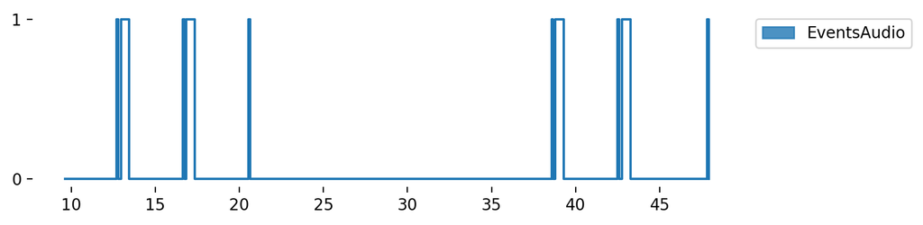

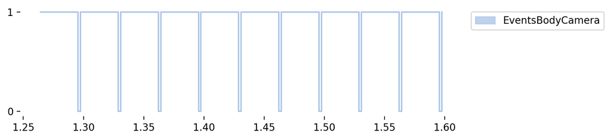

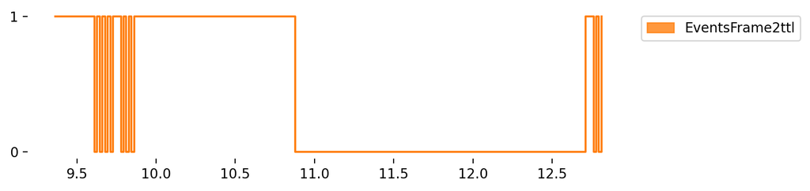

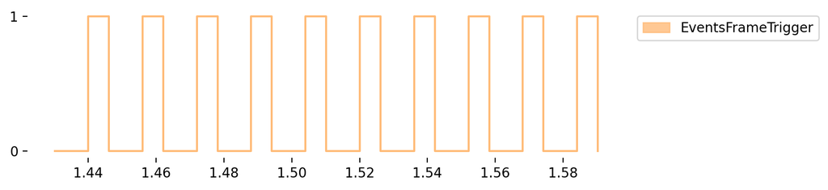

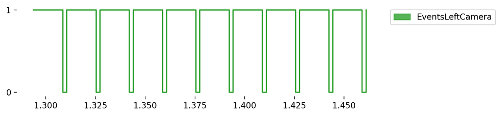

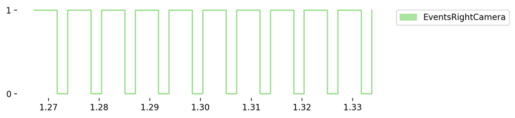

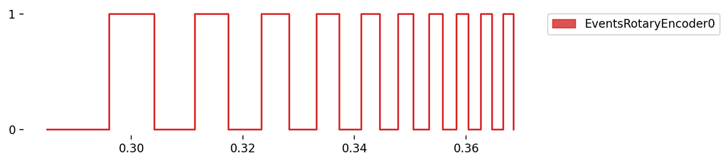

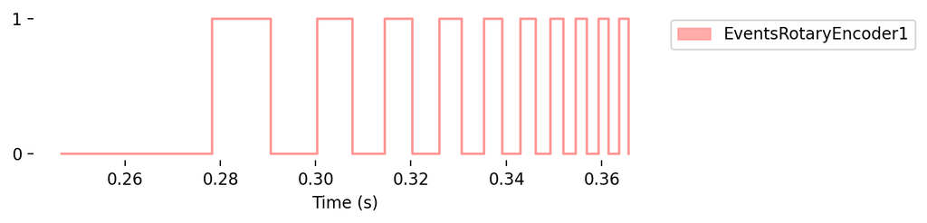

```python
from itertools import cycle


def squares(tscale, polarity, ax=None, yrange=[0, 1], **kwargs):
    """
    Plot rising/falling fronts as a square wave.
    """
    if ax is None:
        ax = plt.gca()
    isort = np.argsort(tscale)
    tscale = tscale[isort]
    polarity = polarity[isort]
    f = np.tile(polarity, (2, 1))
    t = np.concatenate((tscale, np.r_[tscale[1:], tscale[-1]])).reshape(2, f.shape[1])
    ydata = f.T.ravel()
    ydata = (ydata + 1) / 2 * (yrange[1] - yrange[0]) + yrange[0]
    ax.plot(t.T.ravel(), ydata, **kwargs)

num_events = 11  # number of on-off events to plot
cmap = plt.get_cmap('tab20')
color_cycle = cycle([cmap(i) for i in range(cmap.N)])

for i, event_name in enumerate(event_names):
    fig, ax = plt.subplots(figsize=(8, 2), dpi=200)
    event = nwbfile.acquisition[event_name]

    # take first num_events on/off pairs (2 * num_events samples)
    times = event.timestamps[:num_events * 2]
    data = event.data[:num_events * 2].astype(int)

    # find change points (edges)
    changes = np.where(np.diff(data) != 0)[0] + 1
    if changes.size == 0:
        continue

    tscale = times[changes]
    prev_vals = data[changes - 1]
    next_vals = data[changes]

    # +1 for 0->1 (rising), -1 for 1->0 (falling)
    polarity = np.where(
        (prev_vals == 0) & (next_vals == 1), 1,
        np.where((prev_vals == 1) & (next_vals == 0), -1, 0)
    )
    valid = polarity != 0
    tscale = tscale[valid]
    polarity = polarity[valid]

    color = next(color_cycle)

    # plot as square wave
    squares(tscale, polarity, ax=ax, yrange=[0, 1], color=color, linewidth=1.5)

    # if i == 0:
    #     axes[i].set_title("Synchronization Events (acquisition)")

    legend_patches = [mpatches.Patch(color=color, alpha=0.8, label=event_name)]
    ax.legend(handles=legend_patches, bbox_to_anchor=(1.01, 1), loc='upper left')

    ax.set_yticks([0, 1])
    ax.set_yticklabels(['0', '1'])
    ax.set_frame_on(False)

    if i == len(event_names) - 1:
        ax.set_xlabel("Time (s)")
    # turn off grid
    #ax.grid(False)

plt.tight_layout()
plt.show()
```

## Analog Signals

```python
analog_signal_names = [name for name in nwbfile.acquisition if "TimeSeries" in name]
print("=== SYNCHRONIZATION SIGNALS IN ACQUISITION ===")
print("-" * 100)
for name in analog_signal_names:
    print(f"  Name: {name}")
    print(f"  Description: {nwbfile.acquisition[name].description}")
```

```
=== SYNCHRONIZATION SIGNALS IN ACQUISITION ===
----------------------------------------------------------------------------------------------------
  Name: TimeSeriesBpod
  Description: Analog signal from Bpod behavioral control system. This continuous voltage signal encodes behavioral state machine events and timestamps from the Bpod system, which controls stimulus presentation and reward delivery during tasks. The analog encoding allows precise temporal alignment b…
```

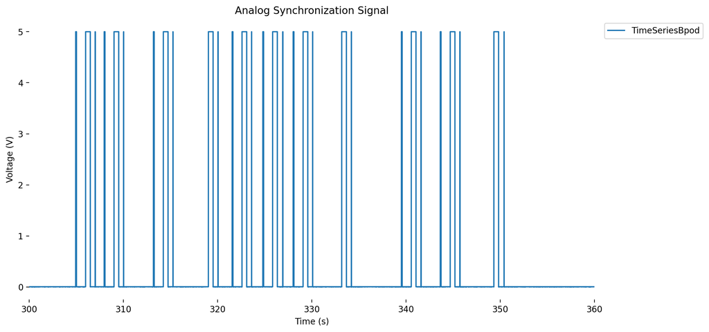

```python
signal_name = "TimeSeriesBpod"
analog_signal = nwbfile.acquisition[signal_name]
rate = analog_signal.rate

# desired time window (minutes)
start_min, end_min = 5, 6
start_sec, end_sec = start_min * 60, end_min * 60

# convert absolute seconds to sample indices (respecting starting_time)
start_idx = int((start_sec - analog_signal.starting_time) * rate)
end_idx = int((end_sec - analog_signal.starting_time) * rate)

# clamp to valid range
start_idx = max(0, start_idx)
end_idx = min(len(analog_signal.data), end_idx)

data_slice = analog_signal.data[start_idx:end_idx] * analog_signal.conversion
times = analog_signal.starting_time + np.arange(start_idx, end_idx) / rate

fig, ax = plt.subplots(dpi=200)
ax.plot(times, data_slice, label=signal_name)
ax.set_xlim(start_sec, end_sec)
ax.set_xlabel("Time (s)")
ax.set_ylabel("Voltage (V)")
ax.set_title("Analog Synchronization Signal")
ax.legend(bbox_to_anchor=(1.01, 1), loc='upper left')
ax.set_frame_on(False)
plt.show()
```

# 5. Behavior

## Epochs (Task vs Passive)

```python
nwbfile.epochs
```

[output not shown]

## Raw Video Data

```python
print("=== RAW VIDEO ===\n")
image_series = []
for name, acq in nwbfile.acquisition.items():
    if "Video" not in name:
        continue
    print(f"{name} - {acq.description}: ")
    print(f"  External file: {acq.external_file[:]}")
    print("-" * 100)
    image_series.append(name)
```

```
=== RAW VIDEO ===

VideoBodyCamera - Raw video from camera recording behavioral and task events.:
  External file: ['./sub-FD-28_ses-81f90b18-e61c-4d32-bbce-3e0c5f33f06c_ecephys+image\\sub-FD-28_ses-81f90b18-e61c-4d32-bbce-3e0c5f33f06c_VideoBodyCamera.mp4']
----------------------------------------------------------------------------------------------------
VideoLeftCamera - Raw video from camera recording behavioral and task events.:
  External file: ['./sub-FD-28_ses-81f90b18-e61c-4d32-bbce-3e0c5f33f06c_ecephys+image\\sub-FD-28_ses-81f90b18-e61c-4d32-bbce-3e0c5f33f06c_VideoLeftCamera.mp4']
----------------------------------------------------------------------------------------------------
VideoRightCamera - Raw video from camera recording behavioral and task events.:
  External file: ['./sub-FD-28_ses-81f90b18-e61c-4d32-bbce-3e0c5f33f06c_ecephys+image\\sub-FD-28_ses-81f90b18-e61c-4d32-bbce-3e0c5f33f06c_VideoRightCamera.mp4']
----------------------------------------------------------------------------------------------------
```

```python
nwbfile.acquisition["VideoBodyCamera"]
```

VideoBodyCamera (ImageSeries)

resolution: -1.0

comments: no comments

description: Raw video from camera recording behavioral and task events.

conversion: 1.0

offset: 0.0

unit: n.a.

**data**

HDF5 dataset

| Data type | uint8 |
| --- | --- |
| Shape | (0, 0, 0) |
| Array size | 0.00 bytes |
| Chunk shape | None |
| Compression | None |
| Compression opts | None |
| Uncompressed size (bytes) | 0 |
| Compressed size (bytes) | 0 |
| Compression ratio | undefined |

[]

**timestamps**

HDF5 dataset

| Data type | float64 |
| --- | --- |
| Shape | (119964,) |
| Array size | 937.22 KiB |
| Chunk shape | (119964,) |
| Compression | gzip |
| Compression opts | 4 |
| Uncompressed size (bytes) | 959712 |
| Compressed size (bytes) | 482800 |
| Compression ratio | 1.987804473902237 |

timestamps_unit: seconds

interval: 1

**external_file**

HDF5 dataset

| Data type | object |
| --- | --- |
| Shape | (1,) |
| Array size | 8.00 bytes |
| Chunk shape | None |
| Compression | None |
| Compression opts | None |
| Uncompressed size (bytes) | 8 |
| Compressed size (bytes) | 16 |
| Compression ratio | 0.5 |

['./sub-FD-28_ses-81f90b18-e61c-4d32-bbce-3e0c5f33f06c_ecephys+image\\sub-FD-28_ses-81f90b18-e61c-4d32-bbce-3e0c5f33f06c_VideoBodyCamera.mp4']

**starting_frame**

NumPy array

| Data type | int64 |
| --- | --- |
| Shape | (1,) |
| Array size | 8.00 bytes |

[0]

format: external